# Moderation Analysis Using PROCESS-Style Models in R

Trauma, Neglect, and Delinquent Behavior

Author

Barboza-Salerno

Published

March 30, 2026

## Overview

This document walks through two moderation analyses using the `processR` package in R — a close analogue to Hayes’ PROCESS macro. In both examples, we examine whether a moderator variable changes the relationship between **childhood trauma** (`tra1`) and **delinquent behavior** (`bcdel1`).

**Moderation** (also called *interaction*) asks: *Does the effect of X on Y depend on a third variable W?* When it does, W is called a **moderator**.

## Setup

We begin by installing and loading all required packages, and reading in the SPSS data file.

```r
# Install processR from GitHub if needed
if (!require(devtools)) install.packages("devtools")
devtools::install_github("cardiomoon/processR", force = FALSE)

# Load packages
library(haven)        # Read SPSS (.sav) files
library(processR)     # PROCESS-style moderation/mediation models
library(ggplot2)      # Plotting
library(dplyr)        # Data manipulation
library(interactions) # Johnson-Neyman technique

# Load data
data <- read_sav("slides/medmod2/pts vex mod mediation.sav")
```

> **Note:** Update the file path in `read_sav()` to match where your `.sav` file is stored on your machine.

## Example 1: Binary Moderator — Neglect (negever)

### Conceptual Model

In this first model:

- **X** = `tra1` — Childhood trauma score
- **Y** = `bcdel1` — Delinquent behavior (outcome)
- **W** = `negever` — History of neglect (0 = No neglect, 1 = Neglect)

The research question is: *Does neglect history change how strongly trauma predicts delinquency?*

### Specifying and Fitting the Model

`regEquation()` from `processR` constructs the regression formula in PROCESS style. The argument `site = list("c")` places the moderator on the path from X to Y (the standard moderation path).

```r
equations <- regEquation(
  X = "tra1",
  Y = "bcdel1",
  moderator = list(name = "negever", site = list("c"))
)

cat(equations)
```

```
bcdel1 ~  tra1+tra1*negever
```

The printed formula shows that `negever` and the product term `tra1:negever` are both entered as predictors — this is the standard way to test moderation via ordinary least squares (OLS) regression.

```r
fit <- lm(as.formula(equations), data = data)
summary(fit)
```

```
Call:
lm(formula = as.formula(equations), data = data)

Residuals:
    Min      1Q  Median      3Q     Max
-12.764  -7.595  -1.168   6.282  34.268

Coefficients:
             Estimate Std. Error t value Pr(>|t|)
(Intercept)  51.19547    1.73784  29.459  < 2e-16 ***
tra1          0.14220    0.03476   4.091 4.54e-05 ***
negever       9.03734    2.36240   3.825 0.000136 ***
tra1:negever -0.10933    0.04634  -2.359 0.018439 *
---
Signif. codes:  0 '***' 0.001 '**' 0.01 '*' 0.05 '.' 0.1 ' ' 1

Residual standard error: 9.328 on 1399 degrees of freedom
  (661 observations deleted due to missingness)
Multiple R-squared:  0.05067,   Adjusted R-squared:  0.04863
F-statistic: 24.89 on 3 and 1399 DF,  p-value: 1.087e-15
```

### Interpreting the Coefficients

```r
modelsSummary(
  list(fit),
  labels = list(X = "tra1", Y = "bcdel1", W = "negever")
)
```

```
===============================================================
                                       Consequent
                         --------------------------------------
                                       bcdel1(Y)
                         -------------------------------------
       Antecedent               Coef     SE      t       p
---------------------------------------------------------------
         tra1(X)          c1   0.142   0.035   4.091   <.001
       negever(W)         c2   9.037   2.362   3.825   <.001
    tra1:negever(X:W)     c3  -0.109   0.046  -2.359    .018
        Constant          iY  51.195   1.738  29.459   <.001
---------------------------------------------------------------
      Observations                       1403
           R2                            0.051
       Adjusted R2                       0.049
       Residual SE                9.328 ( df = 1399)
       F statistic           F(3,1399) = 24.891, p < .001
===============================================================
```

| Term | Estimate | Interpretation |
| --- | --- | --- |
| `tra1` (c1) | 0.142 | Effect of trauma on delinquency **when neglect = 0** (simple slope for the No Neglect group) |
| `negever` (c2) | 9.037 | Difference in delinquency between neglect groups **when trauma = 0** |
| `tra1:negever` (c3) | −0.109 | **The moderation effect**: how much the trauma→delinquency slope changes per unit increase in the moderator |
| Intercept | 51.195 | Predicted delinquency when both `tra1 = 0` and `negever = 0` |

**Key result:** The interaction term `tra1:negever` is statistically significant (*b* = −0.109, *p* = .018). This means the effect of trauma on delinquency **differs** depending on neglect history. Specifically, the positive relationship between trauma and delinquency is *weaker* (flatter slope) for children who experienced neglect compared to those who did not.

The model accounts for about 5% of the variance in delinquency (*R²* = .051), which is modest but the overall model is highly significant (*F*(3, 1399) = 24.89, *p* < .001).

### Visualizing the Interaction

To plot the interaction, we manually compute predicted values across the range of `tra1` for each level of the moderator.

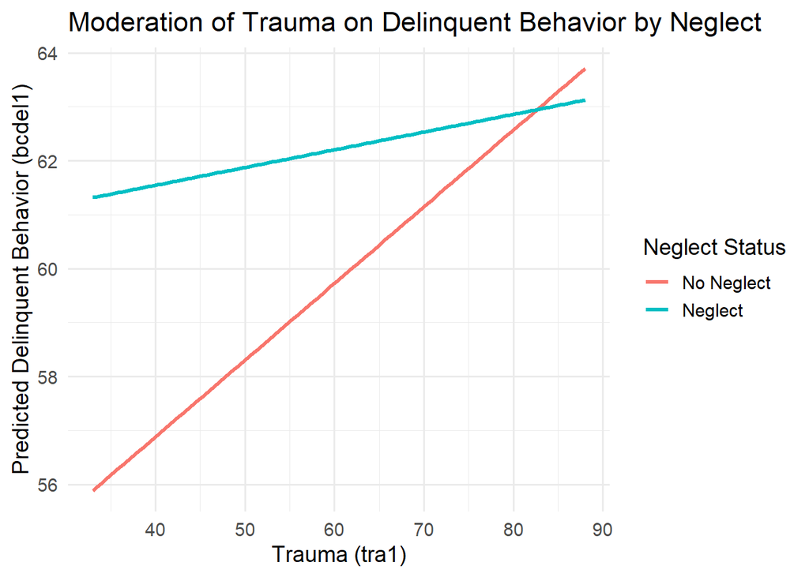

```r
# Extract coefficients
coefs <- coef(fit)
b0 <- coefs[1]
b1 <- coefs["tra1"]
b2 <- coefs["negever"]
b3 <- coefs["tra1:negever"]

# Create a sequence of trauma values
tra_seq <- seq(min(data$tra1, na.rm = TRUE),
               max(data$tra1, na.rm = TRUE),
               length.out = 100)

# Build a grid of trauma × neglect combinations
plot_data <- expand.grid(
  tra1    = tra_seq,
  negever = c(0, 1)
)

# Apply the regression equation: Y = b0 + b1*X + b2*W + b3*X*W
plot_data$pred <- b0 +
  b1 * plot_data$tra1 +
  b2 * plot_data$negever +
  b3 * plot_data$tra1 * plot_data$negever

# Label the moderator levels
plot_data$negever <- factor(plot_data$negever,
                            levels = c(0, 1),
                            labels = c("No Neglect", "Neglect"))

# Plot
ggplot(plot_data, aes(x = tra1, y = pred, color = negever)) +
  geom_line(linewidth = 1.2) +
  labs(
    title = "Moderation of Trauma on Delinquent Behavior by Neglect",
    x     = "Trauma (tra1)",
    y     = "Predicted Delinquent Behavior (bcdel1)",
    color = "Neglect Status"
  ) +
  theme_minimal(base_size = 14)
```

**Reading the plot:** Both groups show a positive trauma→delinquency relationship, but the slope is steeper for the **No Neglect** group. Children without neglect show a stronger increase in delinquency as trauma increases, whereas children with a neglect history show a flatter relationship. This pattern is consistent with the negative interaction coefficient.

## Example 2: Continuous Moderator — Internalizing Distress (cidi1)

### Conceptual Model

In this second model, the moderator is continuous:

- **X** = `tra1` — Childhood trauma score
- **Y** = `bcdel1` — Delinquent behavior
- **W** = `cidi1` — Internalizing distress (CIDI scores; higher = more distress)

The research question becomes: *At what levels of internalizing distress does trauma significantly predict delinquency?*

### Specifying and Fitting the Model

```r
equations_cidi <- regEquation(
  X = "tra1",
  Y = "bcdel1",
  moderator = list(name = "cidi1", site = list("c"))
)

cat(equations_cidi)
```

```
bcdel1 ~  tra1+tra1*cidi1
```

```r
fit_cidi <- lm(as.formula(equations_cidi), data = data)
summary(fit_cidi)
```

```
Call:
lm(formula = as.formula(equations_cidi), data = data)

Residuals:
    Min      1Q  Median      3Q     Max
-19.604  -8.252  -1.233   6.941  32.453

Coefficients:
             Estimate Std. Error t value Pr(>|t|)
(Intercept) 38.042598   4.463865   8.522  < 2e-16 ***
tra1         0.246797   0.084423   2.923  0.00350 **
cidi1        0.450213   0.088369   5.095 3.84e-07 ***
tra1:cidi1  -0.004711   0.001568  -3.005  0.00269 **
---
Signif. codes:  0 '***' 0.001 '**' 0.01 '*' 0.05 '.' 0.1 ' ' 1

Residual standard error: 9.379 on 1905 degrees of freedom
  (155 observations deleted due to missingness)
Multiple R-squared:  0.05867,   Adjusted R-squared:  0.05719
F-statistic: 39.58 on 3 and 1905 DF,  p-value: < 2.2e-16
```

### Interpreting the Coefficients

```r
modelsSummary(
  list(fit_cidi),
  labels = list(X = "tra1", Y = "bcdel1", W = "cidi1")
)
```

```
===============================================================
                                       Consequent
                         --------------------------------------
                                       bcdel1(Y)
                         -------------------------------------
       Antecedent               Coef     SE      t       p
---------------------------------------------------------------
         tra1(X)          c1   0.247   0.084   2.923    .004
        cidi1(W)          c2   0.450   0.088   5.095   <.001
     tra1:cidi1(X:W)      c3  -0.005   0.002  -3.005    .003
        Constant          iY  38.043   4.464   8.522   <.001
---------------------------------------------------------------
      Observations                       1909
           R2                            0.059
       Adjusted R2                       0.057
       Residual SE                9.379 ( df = 1905)
       F statistic           F(3,1905) = 39.580, p < .001
===============================================================
```

| Term | Estimate | Interpretation |
| --- | --- | --- |
| `tra1` (c1) | 0.247 | Effect of trauma on delinquency **when cidi1 = 0** (rarely meaningful for a continuous moderator; interpret conditional effects instead) |
| `cidi1` (c2) | 0.450 | Effect of internalizing distress on delinquency **when trauma = 0** |
| `tra1:cidi1` (c3) | −0.005 | **The moderation effect**: for each 1-unit increase in `cidi1`, the trauma slope decreases by 0.005 |
| Intercept | 38.043 | Predicted delinquency when both `tra1 = 0` and `cidi1 = 0` |

**Key result:** The interaction is again significant (*b* = −0.005, *p* = .003). The negative coefficient means that as internalizing distress increases, the effect of trauma on delinquency weakens. The model explains about 6% of variance (*R²* = .059).

### Conditional Effects at Representative Values

For a continuous moderator, we probe the interaction at three meaningful values of W: the 16th, 50th, and 84th percentiles (analogous to −1 SD, mean, and +1 SD in PROCESS).

The **conditional effect** of X on Y at a given W is:
$$\theta_{X \to Y} = b_1 + b_3 \times W$$

```r
# Extract coefficients
coefs_cidi <- coef(fit_cidi)
b0 <- coefs_cidi[1]
b1 <- coefs_cidi["tra1"]
b2 <- coefs_cidi["cidi1"]
b3 <- coefs_cidi["tra1:cidi1"]

# Percentile values of the moderator
w_vals <- quantile(data$cidi1, probs = c(.16, .50, .84), na.rm = TRUE)

# Compute conditional effects
cond_effects <- data.frame(
  cidi1  = as.numeric(w_vals),
  effect = b1 + b3 * as.numeric(w_vals)
)

cond_effects
```

```
  cidi1      effect
1    39  0.06305985
2    47  0.02537021
3    61 -0.04058667
```

**Interpretation of conditional effects:**

| cidi1 Value | Level | Conditional Effect of Trauma |
| --- | --- | --- |
| 39 (16th %ile) | Low distress | *b* = 0.063, *p* < .05 — trauma **positively** predicts delinquency |
| 47 (50th %ile) | Moderate distress | *b* = 0.025 — smaller positive effect |
| 61 (84th %ile) | High distress | *b* = −0.041 — trauma relationship **reverses** (may not be significant) |

This pattern shows that trauma is most predictive of delinquency among youth with *low* internalizing distress, and the effect diminishes (or reverses) as distress increases.

### Visualizing the Interaction

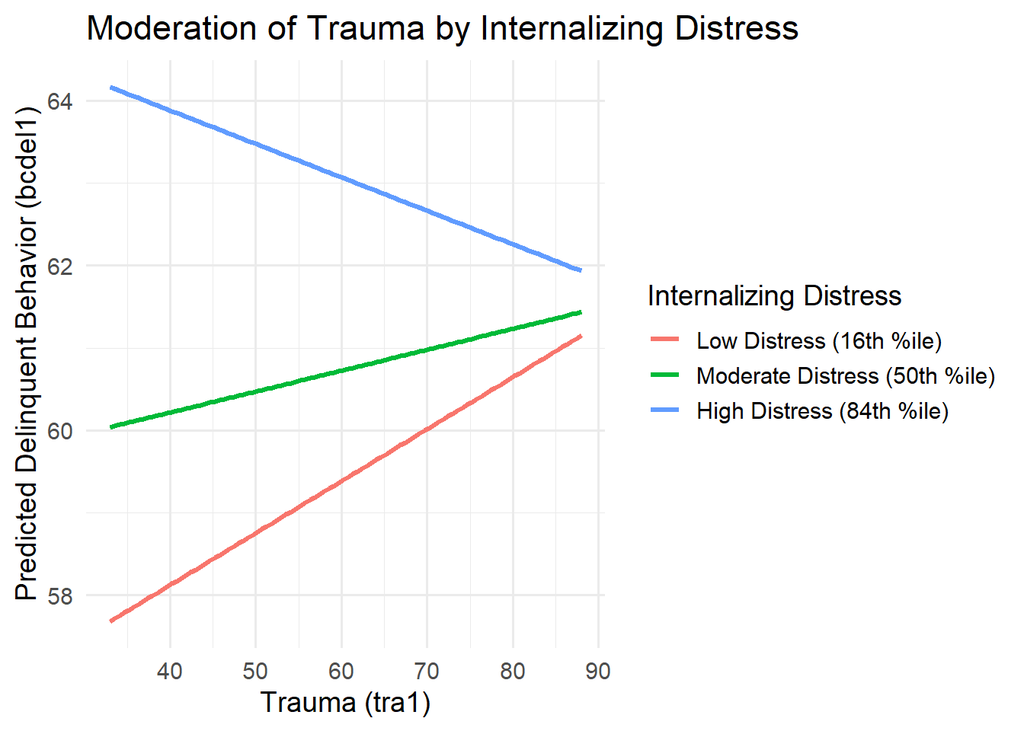

```r
# Range of trauma values
tra_seq <- seq(min(data$tra1, na.rm = TRUE),
               max(data$tra1, na.rm = TRUE),
               length.out = 100)

# Grid of trauma × moderator percentile combinations
plot_data_cidi <- expand.grid(
  tra1  = tra_seq,
  cidi1 = as.numeric(w_vals)
)

# Apply the regression equation
plot_data_cidi$pred <- b0 +
  b1 * plot_data_cidi$tra1 +
  b2 * plot_data_cidi$cidi1 +
  b3 * plot_data_cidi$tra1 * plot_data_cidi$cidi1

# Label the moderator groups
plot_data_cidi$cidi_group <- factor(
  plot_data_cidi$cidi1,
  labels = c("Low Distress (16th %ile)",
             "Moderate Distress (50th %ile)",
             "High Distress (84th %ile)")
)

# Plot
ggplot(plot_data_cidi,
       aes(x = tra1, y = pred, color = cidi_group)) +
  geom_line(linewidth = 1.2) +
  labs(
    title = "Moderation of Trauma by Internalizing Distress",
    x     = "Trauma (tra1)",
    y     = "Predicted Delinquent Behavior (bcdel1)",
    color = "Internalizing Distress"
  ) +
  theme_minimal(base_size = 14)
```

## Johnson-Neyman Analysis

The **Johnson-Neyman (JN) technique** is a more precise way to probe a continuous moderator interaction. Rather than picking arbitrary percentile values, it identifies the *exact range* of W values where the effect of X on Y crosses the significance threshold (*p* = .05).

```
JOHNSON-NEYMAN INTERVAL

When cidi1 is OUTSIDE the interval [40.29, 65.25], the slope of tra1 is p <
.05.

Note: The range of observed values of cidi1 is [34.00, 100.00]
```

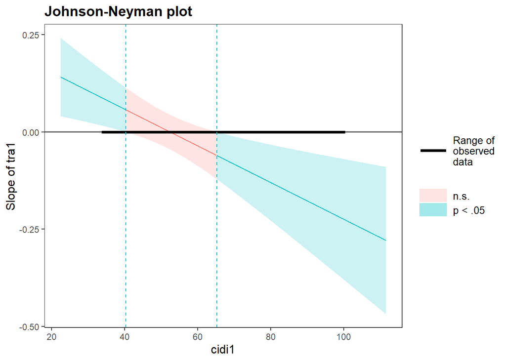

```r
jn <- johnson_neyman(
  model = fit_cidi,
  pred  = tra1,
  modx  = cidi1,
  alpha = 0.05
)

jn
```

### Interpreting the JN Output

The output states:

> *When `cidi1` is **OUTSIDE** the interval [40.29, 65.25], the slope of `tra1` is p < .05.*

This means:

- **Below cidi1 = 40.29:** The effect of trauma on delinquency is statistically significant and *positive* — trauma meaningfully increases delinquency among youth with low internalizing distress.
- **Between 40.29 and 65.25:** The effect is not statistically significant — we cannot confidently say trauma predicts delinquency at these moderate distress levels.
- **Above cidi1 = 65.25:** The effect is again significant, but the slope is *negative* — at very high distress levels, more trauma is associated with *less* delinquency (though this is likely a small and practically complex effect).
- **Observed range of cidi1:** [34, 100], so both boundary values fall within the observed data — this is important because JN boundaries outside the observed range would not be interpretable.

## Summary

| Feature | Example 1 | Example 2 |
| --- | --- | --- |
| Moderator type | Binary (neglect: yes/no) | Continuous (CIDI distress score) |
| Interaction term | `tra1 × negever` | `tra1 × cidi1` |
| Interaction *b* | −0.109, *p* = .018 | −0.005, *p* = .003 |
| Interpretation | Neglect *weakens* the trauma→delinquency link | Higher distress *weakens* the trauma→delinquency link |
| Probing method | Simple slopes at W = 0 and W = 1 | Conditional effects at 16th, 50th, 84th %iles + JN technique |